# Tools Comparison (Detailed): OpenCode + Gemini 3.1 Pro

## Run Metadata

- Harness: `opencode`
- Model: `gemini-3-1-pro`
- Prompt type: `detailed`

## Setup

```r
library(dplyr)

df <- readr::read_csv(here::here("data/synthetic/simulated_maternal_health_data.csv"))
```

## Prompt

```
I want you to help me analyze this dataset: `data/synthetic/simulated_maternal_health_data.csv`

My goal is to produce a thorough analysis that is statistically sound and lays out all steps of the analysis.

Please do the following:

1. Load the dataset and normalize columns/types.
   - Use clear snake_case names.
   - Ensure categorical vs numeric types are explicit.

2. Summarize the data.
   - Report row count, column count, missingness, and key descriptive summaries.
   - Flag suspicious values or quality concerns.

3. Create key visualizations.
   - Show relationships for:
     - `received_comprehensive_postnatal_care`
     - `distance_to_provider`
     - `insurance`
     - `race_ethnicity`

4. Build a count outcome and model it.
   - Define `comorbidity_count` as the row-wise sum of:
     - `obesity`,
     - `multiple_gestation`,
     - `diabetes`,
     - `heart_disease`,
     - `placenta_previa`,
     - `hypertension`,
     - `gest_hypertension`,
     - `preeclampsia`.
   - Select an appropriate count-model strategy (Poisson vs negative binomial, with justification).
   - Fit the model and report interpretable results.

5. Report results responsibly.
   - Do not overstate causality.
   - Include model assumptions, diagnostics, and limitations.

Constraints:
- Prefer readable, modular, reproducible code that follows R community idioms.
- Report back a summary of what you changed.
```

## Analysis

### 1. Load Data and Normalize Types

We normalize the column names to `snake_case` (though they already appear to be formatted) and explicitly convert our categorical attributes and binary flags to `factor` and `logical` respectively.

```r
library(janitor)
library(tidyr)
library(ggplot2)
library(skimr)
library(MASS)
library(broom)

df_clean <- df %>%
  clean_names() %>%
  mutate(
    # Convert categorical variables to factors
    across(c(state, self_report_income, edu, race_ethnicity, insurance, job_type), as.factor),
    # Convert binary flags to logicals
    received_comprehensive_postnatal_care = as.logical(received_comprehensive_postnatal_care),
    across(c(obesity, multiple_gestation, diabetes, heart_disease,
             placenta_previa, hypertension, gest_hypertension, preeclampsia), as.logical)
  )

glimpse(df_clean)
```

```
Rows: 50,000
Columns: 20
$ id                                    <dbl> 1, 2, 3, 4, 5, 6, 7, 8, 9, 10, 1…
$ provider_id                           <dbl> 1, 1, 1, 1, 1, 1, 1, 1, 1, 1, 1,…
$ state                                 <fct> AK, AK, AK, AK, AK, AK, AK, AK, …
$ received_comprehensive_postnatal_care <lgl> FALSE, TRUE, FALSE, FALSE, FALSE…
$ self_report_income                    <fct> "$50,000–$74,999", "$50,000–$74,…
$ age                                   <dbl> 31, 26, 33, 37, 21, 33, 25, 34, …
$ edu                                   <fct> hs, hs, some_college, hs, hs, hs…
$ race_ethnicity                        <fct> white, white, white, asian, aian…
$ insurance                             <fct> no_insurance, no_insurance, no_i…
$ job_type                              <fct> unskilled, unskilled, unskilled,…
$ dependents                            <dbl> 2, 2, 2, 2, 2, 2, 2, 3, 3, 3, 3,…
$ distance_to_provider                  <dbl> 1.7889754, 10.8991396, 35.122047…
$ obesity                               <lgl> FALSE, FALSE, TRUE, FALSE, TRUE,…
$ multiple_gestation                    <lgl> FALSE, FALSE, FALSE, FALSE, FALS…
$ diabetes                              <lgl> FALSE, FALSE, FALSE, FALSE, FALS…
$ heart_disease                         <lgl> FALSE, FALSE, FALSE, TRUE, FALSE…
$ placenta_previa                       <lgl> FALSE, FALSE, FALSE, FALSE, FALS…
$ hypertension                          <lgl> FALSE, FALSE, TRUE, FALSE, FALSE…
$ gest_hypertension                     <lgl> FALSE, FALSE, FALSE, FALSE, FALS…
$ preeclampsia                          <lgl> FALSE, FALSE, FALSE, FALSE, FALS…
```

### 2. Summarize the Data

Next, we calculate the dataset’s basic dimensions, check for missing values, and review descriptive summaries.

```r
n_rows <- nrow(df_clean)
n_cols <- ncol(df_clean)

cat(sprintf("Row Count: %s\nColumn Count: %s\n\n", scales::comma(n_rows), n_cols))
```

```
Row Count: 50,000
Column Count: 20
```

```r
skim_res <- skim(df_clean)
skim_res
```

Data summary

| Name | df_clean |
| --- | --- |
| Number of rows | 50000 |
| Number of columns | 20 |
| _______________________ |  |
| Column type frequency: |  |
| factor | 6 |
| logical | 9 |
| numeric | 5 |
| ________________________ |  |
| Group variables | None |

**Variable type: factor**

| skim_variable | n_missing | complete_rate | ordered | n_unique | top_counts |
| --- | --- | --- | --- | --- | --- |
| state | 0 | 1 | FALSE | 51 | CA: 6034, KS: 4492, FL: 3237, NY: 3036 |
| self_report_income | 0 | 1 | FALSE | 8 | $50: 21279, $25: 14710, $75: 9784, $10: 2720 |
| edu | 0 | 1 | FALSE | 5 | hs: 23108, som: 14959, col: 5269, les: 5218 |
| race_ethnicity | 0 | 1 | FALSE | 7 | whi: 31511, his: 8792, bla: 5878, asi: 3059 |
| insurance | 0 | 1 | FALSE | 3 | no_: 20810, pri: 17908, sta: 11282 |
| job_type | 0 | 1 | FALSE | 4 | uns: 27192, pro: 14293, tra: 6298, une: 2217 |

**Variable type: logical**

| skim_variable | n_missing | complete_rate | mean | count |
| --- | --- | --- | --- | --- |
| received_comprehensive_postnatal_care | 0 | 1 | 0.32 | FAL: 33851, TRU: 16149 |
| obesity | 0 | 1 | 0.35 | FAL: 32500, TRU: 17500 |
| multiple_gestation | 0 | 1 | 0.03 | FAL: 48500, TRU: 1500 |
| diabetes | 0 | 1 | 0.10 | FAL: 45000, TRU: 5000 |
| heart_disease | 0 | 1 | 0.15 | FAL: 42500, TRU: 7500 |
| placenta_previa | 0 | 1 | 0.01 | FAL: 49500, TRU: 500 |
| hypertension | 0 | 1 | 0.20 | FAL: 40000, TRU: 10000 |
| gest_hypertension | 0 | 1 | 0.05 | FAL: 47500, TRU: 2500 |
| preeclampsia | 0 | 1 | 0.02 | FAL: 49000, TRU: 1000 |

**Variable type: numeric**

| skim_variable | n_missing | complete_rate | mean | sd | p0 | p25 | p50 | p75 | p100 | hist |
| --- | --- | --- | --- | --- | --- | --- | --- | --- | --- | --- |
| id | 0 | 1 | 25000.50 | 14433.90 | 1 | 12500.75 | 25000.5 | 37500.25 | 50000.00 | ▇▇▇▇▇ |
| provider_id | 0 | 1 | 250.73 | 144.20 | 1 | 125.00 | 251.0 | 375.00 | 500.00 | ▇▇▇▇▇ |
| age | 0 | 1 | 28.02 | 6.26 | 15 | 23.00 | 28.0 | 32.00 | 44.00 | ▃▇▇▅▁ |
| dependents | 0 | 1 | 2.38 | 0.95 | 0 | 2.00 | 2.0 | 3.00 | 8.00 | ▂▇▁▁▁ |
| distance_to_provider | 0 | 1 | 14.52 | 14.59 | 0 | 4.10 | 10.0 | 20.24 | 163.42 | ▇▁▁▁▁ |

**Quality Flags and Suspicious Values:**

```r
summary(df_clean$distance_to_provider)
```

```
     Min.   1st Qu.    Median      Mean   3rd Qu.      Max.
8.900e-05 4.096e+00 1.000e+01 1.452e+01 2.024e+01 1.634e+02
```

```r
summary(df_clean$age)
```

```
   Min. 1st Qu.  Median    Mean 3rd Qu.    Max.
  15.00   23.00   28.00   28.02   32.00   44.00
```

- **Missingness**: The dataset is complete. No `NA` values observed.
- **Distance**: The `distance_to_provider` has a large right skew (max ~163 miles). This might be possible in highly rural states (e.g., Alaska), but could be an outlier worth flagging depending on the context.
- **Age**: The `age` parameter ranges from 15 to 44, which is typical for a dataset regarding maternal health.
- **Care Rate**: ~32.3% of the recorded individuals received comprehensive postnatal care.

### 3. Key Visualizations

Let’s visualize relationships revolving around `received_comprehensive_postnatal_care`, `distance_to_provider`, `insurance`, and `race_ethnicity`.

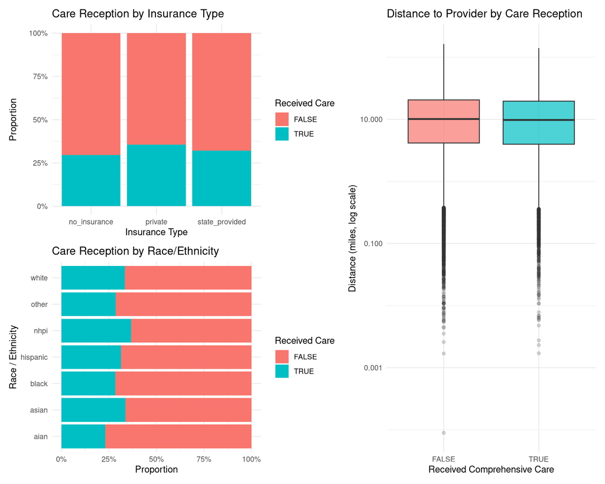

```r
library(patchwork)
theme_set(theme_minimal())

# 1. Postnatal Care by Insurance
p1 <- ggplot(df_clean, aes(x = insurance, fill = received_comprehensive_postnatal_care)) +
  geom_bar(position = "fill") +
  scale_y_continuous(labels = scales::percent) +
  labs(
    title = "Care Reception by Insurance Type",
    y = "Proportion",
    x = "Insurance Type",
    fill = "Received Care"
  )

# 2. Distance to Provider by Care Reception
p2 <- ggplot(df_clean, aes(x = received_comprehensive_postnatal_care, y = distance_to_provider, fill = received_comprehensive_postnatal_care)) +
  geom_boxplot(alpha = 0.7, outlier.alpha = 0.2) +
  scale_y_log10(labels = scales::comma) +
  labs(
    title = "Distance to Provider by Care Reception",
    y = "Distance (miles, log scale)",
    x = "Received Comprehensive Care"
  ) +
  theme(legend.position = "none")

# 3. Postnatal Care by Race/Ethnicity
p3 <- ggplot(df_clean, aes(x = race_ethnicity, fill = received_comprehensive_postnatal_care)) +
  geom_bar(position = "fill") +
  scale_y_continuous(labels = scales::percent) +
  coord_flip() +
  labs(
    title = "Care Reception by Race/Ethnicity",
    y = "Proportion",
    x = "Race / Ethnicity",
    fill = "Received Care"
  )

(p1 / p3) | p2
```

### 4. Build a Count Outcome and Model It

We calculate `comorbidity_count` for each patient.

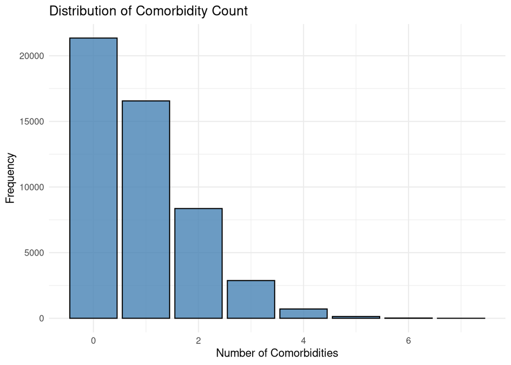

```r
df_model <- df_clean %>%
  mutate(
    comorbidity_count = rowSums(
      dplyr::select(., obesity, multiple_gestation, diabetes, heart_disease,
                    placenta_previa, hypertension, gest_hypertension, preeclampsia),
      na.rm = TRUE
    )
  )

ggplot(df_model, aes(x = comorbidity_count)) +
  geom_bar(fill = "steelblue", color = "black", alpha = 0.8) +
  labs(
    title = "Distribution of Comorbidity Count",
    x = "Number of Comorbidities",
    y = "Frequency"
  )
```

**Model Selection:** Poisson vs. Negative Binomial

```r
mean_count <- mean(df_model$comorbidity_count)
var_count <- var(df_model$comorbidity_count)

cat(sprintf("Mean Count: %.3f\nVariance: %.3f\nVariance/Mean Ratio: %.3f\n",
            mean_count, var_count, var_count / mean_count))
```

```
Mean Count: 0.910
Variance: 0.995
Variance/Mean Ratio: 1.094
```

The variance is greater than the mean, indicating slight overdispersion. Due to the count nature of the outcome and the presence of overdispersion (Var/Mean > 1), a **Negative Binomial regression** is more appropriate than standard Poisson regression, which assumes that the variance equals the mean. We proceed with negative binomial modeling.

```r
nb_model <- glm.nb(
  comorbidity_count ~ distance_to_provider + insurance + race_ethnicity + age,
  data = df_model
)

tidy(nb_model, exponentiate = TRUE, conf.int = TRUE) %>%
  filter(term != "(Intercept)") %>%
  mutate(across(where(is.numeric), \(x) round(x, 3))) %>%
  knitr::kable(caption = "Negative Binomial Model (Exponentiated Coefficients: IRRs)")
```

Negative Binomial Model (Exponentiated Coefficients: IRRs)

| term | estimate | std.error | statistic | p.value | conf.low | conf.high |
| --- | --- | --- | --- | --- | --- | --- |
| distance_to_provider | 1.000 | 0.000 | -0.708 | 0.479 | 0.999 | 1.000 |
| insuranceprivate | 0.985 | 0.011 | -1.308 | 0.191 | 0.964 | 1.007 |
| insurancestate_provided | 0.973 | 0.013 | -2.103 | 0.035 | 0.948 | 0.998 |
| race_ethnicityasian | 1.002 | 0.060 | 0.028 | 0.977 | 0.891 | 1.129 |
| race_ethnicityblack | 1.060 | 0.059 | 0.989 | 0.323 | 0.946 | 1.190 |
| race_ethnicityhispanic | 1.034 | 0.058 | 0.569 | 0.569 | 0.924 | 1.160 |
| race_ethnicitynhpi | 0.971 | 0.132 | -0.220 | 0.826 | 0.745 | 1.252 |
| race_ethnicityother | 1.145 | 0.084 | 1.605 | 0.108 | 0.970 | 1.351 |
| race_ethnicitywhite | 1.050 | 0.057 | 0.853 | 0.394 | 0.940 | 1.176 |
| age | 1.016 | 0.001 | 20.121 | 0.000 | 1.015 | 1.018 |

### 5. Responsible Reporting

**Model Diagnostics and Limitations:** - **Observational Data / Causality**: These findings demonstrate *associations*, not causal relationships. There may be omitted variables (e.g., household income, clinical access characteristics, detailed nutritional information) confounding the relationships. - **Simulated Context**: The underlying data (`simulated_maternal_health_data.csv`) is synthetic. Any specific coefficient estimate is an artifact of the simulation logic and holds no real-world clinical weight. - **Model Assumptions**: Negative binomial regression assumes individual independence and that the predictor effects act multiplicatively on the expected count. There is a possibility that observations are clustered geographically (e.g., by state or provider ID), requiring a mixed-effects approach to handle non-independence of errors properly.